# Risk Factor Analysis

## Outcome Variable

**Outcome Variable:** sstunted

## Predictor Variables

**Intervention Variable:** vagbrth

**Adjustment Set:**

unadjusted

## Stratifying Variables

The analysis was stratified on these variable(s):

- agecat
- studyid
- country

## Data Summary

| agecat | studyid | country | vagbrth | sstunted | n_cell | n |
| --- | --- | --- | --- | --- | --- | --- |
| Birth | CMC-V-BCS-2002 | INDIA | 0 | 0 | 10 | 92 |
| Birth | CMC-V-BCS-2002 | INDIA | 0 | 1 | 1 | 92 |
| Birth | CMC-V-BCS-2002 | INDIA | 1 | 0 | 78 | 92 |
| Birth | CMC-V-BCS-2002 | INDIA | 1 | 1 | 3 | 92 |
| Birth | IRC | INDIA | 0 | 0 | 67 | 388 |
| Birth | IRC | INDIA | 0 | 1 | 1 | 388 |
| Birth | IRC | INDIA | 1 | 0 | 305 | 388 |
| Birth | IRC | INDIA | 1 | 1 | 15 | 388 |
| Birth | NIH-Crypto | BANGLADESH | 0 | 0 | 185 | 477 |
| Birth | NIH-Crypto | BANGLADESH | 0 | 1 | 1 | 477 |
| Birth | NIH-Crypto | BANGLADESH | 1 | 0 | 290 | 477 |
| Birth | NIH-Crypto | BANGLADESH | 1 | 1 | 1 | 477 |
| Birth | PROBIT | BELARUS | 0 | 0 | 1596 | 13893 |
| Birth | PROBIT | BELARUS | 0 | 1 | 1 | 13893 |
| Birth | PROBIT | BELARUS | 1 | 0 | 12292 | 13893 |
| Birth | PROBIT | BELARUS | 1 | 1 | 4 | 13893 |
| Birth | PROVIDE | BANGLADESH | 0 | 0 | 107 | 539 |
| Birth | PROVIDE | BANGLADESH | 0 | 1 | 1 | 539 |
| Birth | PROVIDE | BANGLADESH | 1 | 0 | 428 | 539 |
| Birth | PROVIDE | BANGLADESH | 1 | 1 | 3 | 539 |
| Birth | ZVITAMBO | ZIMBABWE | 0 | 0 | 1136 | 13761 |
| Birth | ZVITAMBO | ZIMBABWE | 0 | 1 | 30 | 13761 |
| Birth | ZVITAMBO | ZIMBABWE | 1 | 0 | 12191 | 13761 |
| Birth | ZVITAMBO | ZIMBABWE | 1 | 1 | 404 | 13761 |
| 6 months | CMC-V-BCS-2002 | INDIA | 0 | 0 | 23 | 369 |
| 6 months | CMC-V-BCS-2002 | INDIA | 0 | 1 | 2 | 369 |
| 6 months | CMC-V-BCS-2002 | INDIA | 1 | 0 | 304 | 369 |
| 6 months | CMC-V-BCS-2002 | INDIA | 1 | 1 | 40 | 369 |
| 6 months | IRC | INDIA | 0 | 0 | 64 | 407 |
| 6 months | IRC | INDIA | 0 | 1 | 5 | 407 |
| 6 months | IRC | INDIA | 1 | 0 | 314 | 407 |
| 6 months | IRC | INDIA | 1 | 1 | 24 | 407 |
| 6 months | NIH-Crypto | BANGLADESH | 0 | 0 | 183 | 457 |
| 6 months | NIH-Crypto | BANGLADESH | 0 | 1 | 4 | 457 |
| 6 months | NIH-Crypto | BANGLADESH | 1 | 0 | 258 | 457 |
| 6 months | NIH-Crypto | BANGLADESH | 1 | 1 | 12 | 457 |
| 6 months | PROBIT | BELARUS | 0 | 0 | 1781 | 15760 |
| 6 months | PROBIT | BELARUS | 0 | 1 | 18 | 15760 |
| 6 months | PROBIT | BELARUS | 1 | 0 | 13802 | 15760 |
| 6 months | PROBIT | BELARUS | 1 | 1 | 159 | 15760 |
| 6 months | PROVIDE | BANGLADESH | 0 | 0 | 137 | 604 |
| 6 months | PROVIDE | BANGLADESH | 0 | 1 | 2 | 604 |
| 6 months | PROVIDE | BANGLADESH | 1 | 0 | 453 | 604 |
| 6 months | PROVIDE | BANGLADESH | 1 | 1 | 12 | 604 |
| 6 months | TanzaniaChild2 | TANZANIA, UNITED REPUBLIC OF | 0 | 0 | 189 | 2005 |
| 6 months | TanzaniaChild2 | TANZANIA, UNITED REPUBLIC OF | 0 | 1 | 0 | 2005 |
| 6 months | TanzaniaChild2 | TANZANIA, UNITED REPUBLIC OF | 1 | 0 | 1797 | 2005 |
| 6 months | TanzaniaChild2 | TANZANIA, UNITED REPUBLIC OF | 1 | 1 | 19 | 2005 |
| 6 months | ZVITAMBO | ZIMBABWE | 0 | 0 | 714 | 8601 |
| 6 months | ZVITAMBO | ZIMBABWE | 0 | 1 | 26 | 8601 |
| 6 months | ZVITAMBO | ZIMBABWE | 1 | 0 | 7536 | 8601 |
| 6 months | ZVITAMBO | ZIMBABWE | 1 | 1 | 325 | 8601 |
| 24 months | CMC-V-BCS-2002 | INDIA | 0 | 0 | 16 | 371 |
| 24 months | CMC-V-BCS-2002 | INDIA | 0 | 1 | 8 | 371 |
| 24 months | CMC-V-BCS-2002 | INDIA | 1 | 0 | 230 | 371 |
| 24 months | CMC-V-BCS-2002 | INDIA | 1 | 1 | 117 | 371 |
| 24 months | IRC | INDIA | 0 | 0 | 66 | 409 |
| 24 months | IRC | INDIA | 0 | 1 | 3 | 409 |
| 24 months | IRC | INDIA | 1 | 0 | 302 | 409 |
| 24 months | IRC | INDIA | 1 | 1 | 38 | 409 |
| 24 months | NIH-Crypto | BANGLADESH | 0 | 0 | 92 | 260 |
| 24 months | NIH-Crypto | BANGLADESH | 0 | 1 | 7 | 260 |
| 24 months | NIH-Crypto | BANGLADESH | 1 | 0 | 146 | 260 |
| 24 months | NIH-Crypto | BANGLADESH | 1 | 1 | 15 | 260 |
| 24 months | PROBIT | BELARUS | 0 | 0 | 465 | 4035 |
| 24 months | PROBIT | BELARUS | 0 | 1 | 7 | 4035 |
| 24 months | PROBIT | BELARUS | 1 | 0 | 3505 | 4035 |
| 24 months | PROBIT | BELARUS | 1 | 1 | 58 | 4035 |
| 24 months | PROVIDE | BANGLADESH | 0 | 0 | 130 | 578 |
| 24 months | PROVIDE | BANGLADESH | 0 | 1 | 7 | 578 |
| 24 months | PROVIDE | BANGLADESH | 1 | 0 | 396 | 578 |
| 24 months | PROVIDE | BANGLADESH | 1 | 1 | 45 | 578 |
| 24 months | TanzaniaChild2 | TANZANIA, UNITED REPUBLIC OF | 0 | 0 | 2 | 6 |
| 24 months | TanzaniaChild2 | TANZANIA, UNITED REPUBLIC OF | 0 | 1 | 0 | 6 |
| 24 months | TanzaniaChild2 | TANZANIA, UNITED REPUBLIC OF | 1 | 0 | 3 | 6 |
| 24 months | TanzaniaChild2 | TANZANIA, UNITED REPUBLIC OF | 1 | 1 | 1 | 6 |
| 24 months | ZVITAMBO | ZIMBABWE | 0 | 0 | 123 | 1619 |
| 24 months | ZVITAMBO | ZIMBABWE | 0 | 1 | 10 | 1619 |
| 24 months | ZVITAMBO | ZIMBABWE | 1 | 0 | 1321 | 1619 |
| 24 months | ZVITAMBO | ZIMBABWE | 1 | 1 | 165 | 1619 |

The following strata were considered:

- agecat: 24 months, studyid: CMC-V-BCS-2002, country: INDIA
- agecat: 24 months, studyid: IRC, country: INDIA
- agecat: 24 months, studyid: NIH-Crypto, country: BANGLADESH
- agecat: 24 months, studyid: PROBIT, country: BELARUS
- agecat: 24 months, studyid: PROVIDE, country: BANGLADESH
- agecat: 24 months, studyid: TanzaniaChild2, country: TANZANIA, UNITED REPUBLIC OF
- agecat: 24 months, studyid: ZVITAMBO, country: ZIMBABWE
- agecat: 6 months, studyid: CMC-V-BCS-2002, country: INDIA
- agecat: 6 months, studyid: IRC, country: INDIA
- agecat: 6 months, studyid: NIH-Crypto, country: BANGLADESH
- agecat: 6 months, studyid: PROBIT, country: BELARUS
- agecat: 6 months, studyid: PROVIDE, country: BANGLADESH
- agecat: 6 months, studyid: TanzaniaChild2, country: TANZANIA, UNITED REPUBLIC OF
- agecat: 6 months, studyid: ZVITAMBO, country: ZIMBABWE
- agecat: Birth, studyid: CMC-V-BCS-2002, country: INDIA
- agecat: Birth, studyid: IRC, country: INDIA
- agecat: Birth, studyid: NIH-Crypto, country: BANGLADESH
- agecat: Birth, studyid: PROBIT, country: BELARUS
- agecat: Birth, studyid: PROVIDE, country: BANGLADESH
- agecat: Birth, studyid: ZVITAMBO, country: ZIMBABWE

### Dropped Strata

Some strata were dropped due to rare outcomes:

- agecat: Birth, studyid: CMC-V-BCS-2002, country: INDIA
- agecat: Birth, studyid: IRC, country: INDIA
- agecat: Birth, studyid: NIH-Crypto, country: BANGLADESH
- agecat: Birth, studyid: PROBIT, country: BELARUS
- agecat: Birth, studyid: PROVIDE, country: BANGLADESH
- agecat: 6 months, studyid: CMC-V-BCS-2002, country: INDIA
- agecat: 6 months, studyid: NIH-Crypto, country: BANGLADESH
- agecat: 6 months, studyid: PROVIDE, country: BANGLADESH
- agecat: 6 months, studyid: TanzaniaChild2, country: TANZANIA, UNITED REPUBLIC OF
- agecat: 24 months, studyid: IRC, country: INDIA
- agecat: 24 months, studyid: TanzaniaChild2, country: TANZANIA, UNITED REPUBLIC OF

## Methods Detail

We’re interested in the causal parameters $E[Y_a]$ for all values of $a \in \mathcal{A}$. These parameters represent the mean outcome if, possibly contrary to fact, we intervened to set all units to have $A=a$. Under the randomization and positivity assumptions, these are identified by the statistical parameters $\psi_a=E_W[E_{Y|A,W}(Y|A=a,W)]$. In addition, we’re interested in the mean of $Y$, $E[Y]$ under no intervention (the observed mean). We will estimate these parameters by using SuperLearner to fit the relevant likelihood factors – $E_{Y|A,W}(Y|A=a,W)$ and $p(A=a|W)$, and then updating our likelihood fit using a joint TMLE.

For unadjusted analyses ($W=\{\}$), initial likelihoods were estimated using Lrnr_glm to estimate the simple $E(Y|A)$ and Lrnr_mean to estimate $p(A)$. For adjusted analyses, a small library containing Lrnr_glmnet, Lrnr_xgboost, and Lrnr_mean was used.

Having estimated these parameters, we will then use the delta method to estimate relative risks and attributable risks relative to a prespecified baseline level of $A$.

# Results Detail

## Results Plots

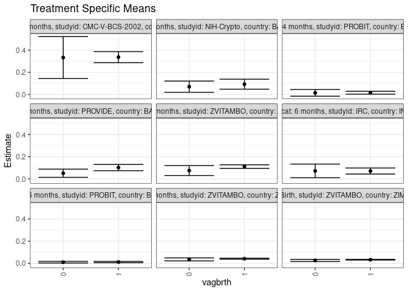

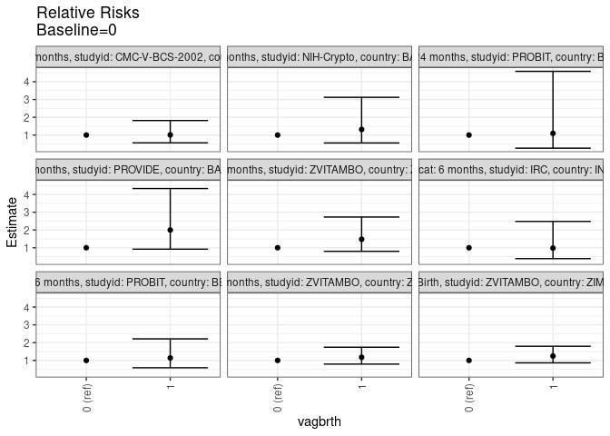

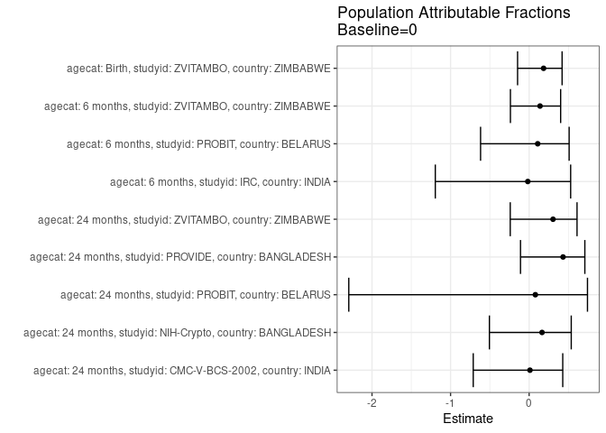

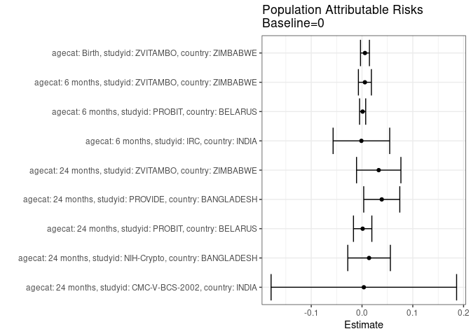

## Results Table

### Parameter: TSM

| agecat | studyid | country | intervention_level | baseline_level | estimate | ci_lower | ci_upper |
| --- | --- | --- | --- | --- | --- | --- | --- |
| Birth | ZVITAMBO | ZIMBABWE | 0 | NA | 0.0257290 | 0.0166410 | 0.0348169 |
| Birth | ZVITAMBO | ZIMBABWE | 1 | NA | 0.0320762 | 0.0289989 | 0.0351536 |
| 6 months | IRC | INDIA | 0 | NA | 0.0724638 | 0.0112169 | 0.1337106 |
| 6 months | IRC | INDIA | 1 | NA | 0.0710059 | 0.0435916 | 0.0984202 |
| 6 months | PROBIT | BELARUS | 0 | NA | 0.0100056 | 0.0022546 | 0.0177565 |
| 6 months | PROBIT | BELARUS | 1 | NA | 0.0113889 | 0.0054839 | 0.0172938 |
| 6 months | ZVITAMBO | ZIMBABWE | 0 | NA | 0.0351351 | 0.0218685 | 0.0484018 |
| 6 months | ZVITAMBO | ZIMBABWE | 1 | NA | 0.0413433 | 0.0369422 | 0.0457445 |
| 24 months | CMC-V-BCS-2002 | INDIA | 0 | NA | 0.3333333 | 0.1444810 | 0.5221856 |
| 24 months | CMC-V-BCS-2002 | INDIA | 1 | NA | 0.3371758 | 0.2873681 | 0.3869835 |
| 24 months | NIH-Crypto | BANGLADESH | 0 | NA | 0.0707071 | 0.0201159 | 0.1212983 |
| 24 months | NIH-Crypto | BANGLADESH | 1 | NA | 0.0931677 | 0.0481827 | 0.1381527 |
| 24 months | PROBIT | BELARUS | 0 | NA | 0.0148305 | -0.0151878 | 0.0448488 |
| 24 months | PROBIT | BELARUS | 1 | NA | 0.0162784 | 0.0035356 | 0.0290213 |
| 24 months | PROVIDE | BANGLADESH | 0 | NA | 0.0510949 | 0.0141917 | 0.0879981 |
| 24 months | PROVIDE | BANGLADESH | 1 | NA | 0.1020408 | 0.0737647 | 0.1303170 |
| 24 months | ZVITAMBO | ZIMBABWE | 0 | NA | 0.0751880 | 0.0303591 | 0.1200168 |
| 24 months | ZVITAMBO | ZIMBABWE | 1 | NA | 0.1110363 | 0.0950574 | 0.1270153 |

### Parameter: E(Y)

| agecat | studyid | country | intervention_level | baseline_level | estimate | ci_lower | ci_upper |
| --- | --- | --- | --- | --- | --- | --- | --- |
| Birth | ZVITAMBO | ZIMBABWE | NA | NA | 0.0315384 | 0.0286183 | 0.0344585 |
| 6 months | IRC | INDIA | NA | NA | 0.0712531 | 0.0462303 | 0.0962759 |
| 6 months | PROBIT | BELARUS | NA | NA | 0.0112310 | 0.0054733 | 0.0169886 |
| 6 months | ZVITAMBO | ZIMBABWE | NA | NA | 0.0408092 | 0.0366277 | 0.0449907 |
| 24 months | CMC-V-BCS-2002 | INDIA | NA | NA | 0.3369272 | 0.2887662 | 0.3850883 |
| 24 months | NIH-Crypto | BANGLADESH | NA | NA | 0.0846154 | 0.0507212 | 0.1185095 |
| 24 months | PROBIT | BELARUS | NA | NA | 0.0161090 | 0.0017796 | 0.0304385 |
| 24 months | PROVIDE | BANGLADESH | NA | NA | 0.0899654 | 0.0666186 | 0.1133122 |
| 24 months | ZVITAMBO | ZIMBABWE | NA | NA | 0.1080914 | 0.0929623 | 0.1232206 |

### Parameter: RR

| agecat | studyid | country | intervention_level | baseline_level | estimate | ci_lower | ci_upper |
| --- | --- | --- | --- | --- | --- | --- | --- |
| Birth | ZVITAMBO | ZIMBABWE | 0 | 0 | 1.0000000 | 1.0000000 | 1.000000 |
| Birth | ZVITAMBO | ZIMBABWE | 1 | 0 | 1.2466958 | 0.8645736 | 1.797707 |
| 6 months | IRC | INDIA | 0 | 0 | 1.0000000 | 1.0000000 | 1.000000 |
| 6 months | IRC | INDIA | 1 | 0 | 0.9798817 | 0.3869206 | 2.481564 |
| 6 months | PROBIT | BELARUS | 0 | 0 | 1.0000000 | 1.0000000 | 1.000000 |
| 6 months | PROBIT | BELARUS | 1 | 0 | 1.1382542 | 0.5855673 | 2.212594 |
| 6 months | ZVITAMBO | ZIMBABWE | 0 | 0 | 1.0000000 | 1.0000000 | 1.000000 |
| 6 months | ZVITAMBO | ZIMBABWE | 1 | 0 | 1.1766951 | 0.7948521 | 1.741974 |
| 24 months | CMC-V-BCS-2002 | INDIA | 0 | 0 | 1.0000000 | 1.0000000 | 1.000000 |
| 24 months | CMC-V-BCS-2002 | INDIA | 1 | 0 | 1.0115274 | 0.5632472 | 1.816587 |
| 24 months | NIH-Crypto | BANGLADESH | 0 | 0 | 1.0000000 | 1.0000000 | 1.000000 |
| 24 months | NIH-Crypto | BANGLADESH | 1 | 0 | 1.3176575 | 0.5558122 | 3.123755 |
| 24 months | PROBIT | BELARUS | 0 | 0 | 1.0000000 | 1.0000000 | 1.000000 |
| 24 months | PROBIT | BELARUS | 1 | 0 | 1.0976304 | 0.2628358 | 4.583821 |
| 24 months | PROVIDE | BANGLADESH | 0 | 0 | 1.0000000 | 1.0000000 | 1.000000 |
| 24 months | PROVIDE | BANGLADESH | 1 | 0 | 1.9970845 | 0.9213693 | 4.328717 |
| 24 months | ZVITAMBO | ZIMBABWE | 0 | 0 | 1.0000000 | 1.0000000 | 1.000000 |
| 24 months | ZVITAMBO | ZIMBABWE | 1 | 0 | 1.4767833 | 0.7997323 | 2.727024 |

### Parameter: PAR

| agecat | studyid | country | intervention_level | baseline_level | estimate | ci_lower | ci_upper |
| --- | --- | --- | --- | --- | --- | --- | --- |
| Birth | ZVITAMBO | ZIMBABWE | 0 | NA | 0.0058094 | -0.0029725 | 0.0145913 |
| 6 months | IRC | INDIA | 0 | NA | -0.0012107 | -0.0569370 | 0.0545156 |
| 6 months | PROBIT | BELARUS | 0 | NA | 0.0012254 | -0.0047972 | 0.0072480 |
| 6 months | ZVITAMBO | ZIMBABWE | 0 | NA | 0.0056741 | -0.0071010 | 0.0184492 |
| 24 months | CMC-V-BCS-2002 | INDIA | 0 | NA | 0.0035939 | -0.1790816 | 0.1862693 |
| 24 months | NIH-Crypto | BANGLADESH | 0 | NA | 0.0139083 | -0.0280339 | 0.0558505 |
| 24 months | PROBIT | BELARUS | 0 | NA | 0.0012785 | -0.0168090 | 0.0193660 |
| 24 months | PROVIDE | BANGLADESH | 0 | NA | 0.0388705 | 0.0033552 | 0.0743858 |
| 24 months | ZVITAMBO | ZIMBABWE | 0 | NA | 0.0329034 | -0.0107811 | 0.0765879 |

### Parameter: PAF

| agecat | studyid | country | intervention_level | baseline_level | estimate | ci_lower | ci_upper |
| --- | --- | --- | --- | --- | --- | --- | --- |
| Birth | ZVITAMBO | ZIMBABWE | 0 | NA | 0.1842014 | -0.1469755 | 0.4197545 |
| 6 months | IRC | INDIA | 0 | NA | -0.0169915 | -1.1942765 | 0.5286502 |
| 6 months | PROBIT | BELARUS | 0 | NA | 0.1091096 | -0.6179860 | 0.5094607 |
| 6 months | ZVITAMBO | ZIMBABWE | 0 | NA | 0.1390390 | -0.2380581 | 0.4012770 |
| 24 months | CMC-V-BCS-2002 | INDIA | 0 | NA | 0.0106667 | -0.7113840 | 0.4280766 |
| 24 months | NIH-Crypto | BANGLADESH | 0 | NA | 0.1643710 | -0.5055688 | 0.5362046 |
| 24 months | PROBIT | BELARUS | 0 | NA | 0.0793677 | -2.2956083 | 0.7428202 |
| 24 months | PROVIDE | BANGLADESH | 0 | NA | 0.4320606 | -0.1095941 | 0.7093035 |
| 24 months | ZVITAMBO | ZIMBABWE | 0 | NA | 0.3044039 | -0.2402677 | 0.6098794 |